# Analyzing eCommerce data

Tommy Wang, Sadaf Sultan, Jean-Francois Lafon, Alexandre Le Cann

# Importing the data

First step is of course to import the data.

Here swe have two data files:

- “Anonymized_transactions_all.csv” which compiles all transactions that happened between January 1st and February 7th. Each row of the file corresponds to the purchase of one item (when various items are bought during the same transaction, several lines are created). The different fields listed in the file are:
- Order numer: unique identification of the order
- SKU number: identifier of an item in the ecommerce database
- Unit price of the item purchased
- Price paid for the item (can be different from the item price if there are promotions for example)
- Date of the order
- Time of the order
- Payment method used
- Price paid for the whole order
- Anonymized name of the customer (“Anonym”+several digits)
- “Categories_all.csv” contains a breakdown of each item into sub categories. Each line corresponds to an item that can be purchased through the ecommerce website. The different fields are:
- SKU number: the unique identifier for each item
- Item description: a sentence describing the item
- Category of the item
- Sub-category of the item
- Sub-sub-category of the item

```r
# This simply reads the CSV files and creates two variables containing text
# data
Transaction_data <- read.csv(Transaction_datafile_name, sep = ";")
Categories_data <- read.csv(Categories_datafile_name, sep = ";")



# For later use, we have to remove the items that don't have any category
# from the dataset Variable SKU_Cat will be a vector containing the
# categories and whose names are the SKUs present in the datafile
# 'Categories_all.csv'
SKU_Cat <- Categories_data[, "Category"]
names(SKU_Cat) <- Categories_data[, "SKU"]

# We have to exclude some customers, linked to fake accounts (created for
# debug purposes by the ecommerce website)

Customer_blacklist = c("Customer254", "Customer262", "Customer302", "Customer9869")
Transaction_blacklist = NULL

# Next, let's add to this blacklist the transactions involving SKU not
# present in the datafile 'Categories_all.csv'
for (i in 1:nrow(Transaction_data)) {
    if (!(as.character(Transaction_data[i, "SKU"]) %in% names(SKU_Cat)) || (as.character(Transaction_data[i,
        "Anonym"]) %in% Customer_blacklist)) {
        Transaction_blacklist = c(Transaction_blacklist, i)
    }
}

# we keep only the ones that are not on the blacklist
Transaction_data <- Transaction_data[-Transaction_blacklist, ]


nbTransactions = nrow(Transaction_data)
```

After having imported the data, the idea is to create a new variable, that sums up the items bought by each customer.

```r
# We have to figure out at first the list of customers and of items sold
Customer_list = as.character(Transaction_data[1, "Anonym"])
ItemsSold_list = as.character(Transaction_data[1, "SKU"])
Orders_list = as.character(Transaction_data[1, "Order.Number"])
for (i in 2:nbTransactions) {
    if (!(as.character(Transaction_data[i, "Anonym"]) %in% Customer_list)) {
        Customer_list <- c(Customer_list, as.character(Transaction_data[i, "Anonym"]))
    }
    if (!(as.character(Transaction_data[i, "SKU"]) %in% ItemsSold_list)) {
        ItemsSold_list <- c(ItemsSold_list, as.character(Transaction_data[i,
            "SKU"]))
    }
    if (!(as.character(Transaction_data[i, "Order.Number"]) %in% Orders_list)) {
        Orders_list <- c(Orders_list, as.character(Transaction_data[i, "Order.Number"]))
    }
}

# The number of unique customers and different items sold is then easy to
# compute
nbCustomers = length(Customer_list)
nbItemsSold = length(ItemsSold_list)
nbOrders = length(Orders_list)

# Then we create a matrix that we will populate with the actual transactions
Sales_Cust_Items = matrix(0 * 1:(nbCustomers * nbItemsSold), ncol = nbItemsSold,
    nrow = nbCustomers)
colnames(Sales_Cust_Items) <- ItemsSold_list
rownames(Sales_Cust_Items) <- Customer_list

for (i in 1:nbTransactions) {
    itemsold = as.character(Transaction_data[i, "SKU"])
    customer = as.character(Transaction_data[i, "Anonym"])
    Sales_Cust_Items[customer, itemsold] <- Sales_Cust_Items[customer, itemsold] +
        1
}

# And we create a matrix that we will populate with the actual orders
Sales_Cust_Orders = matrix(0 * 1:(nbCustomers * nbOrders), ncol = nbOrders,
    nrow = nbCustomers)
colnames(Sales_Cust_Orders) <- Orders_list
rownames(Sales_Cust_Orders) <- Customer_list

for (i in 1:nbTransactions) {
    order = as.character(Transaction_data[i, "Order.Number"])
    customer = as.character(Transaction_data[i, "Anonym"])
    Sales_Cust_Orders[customer, order] <- Sales_Cust_Orders[customer, order] +
        1
}
```

We have created 2 variables: Sales_Cust_Items and Sales_Cust_Orders

# Basic data visualizations

## Distribution of the number of items ordered per customer

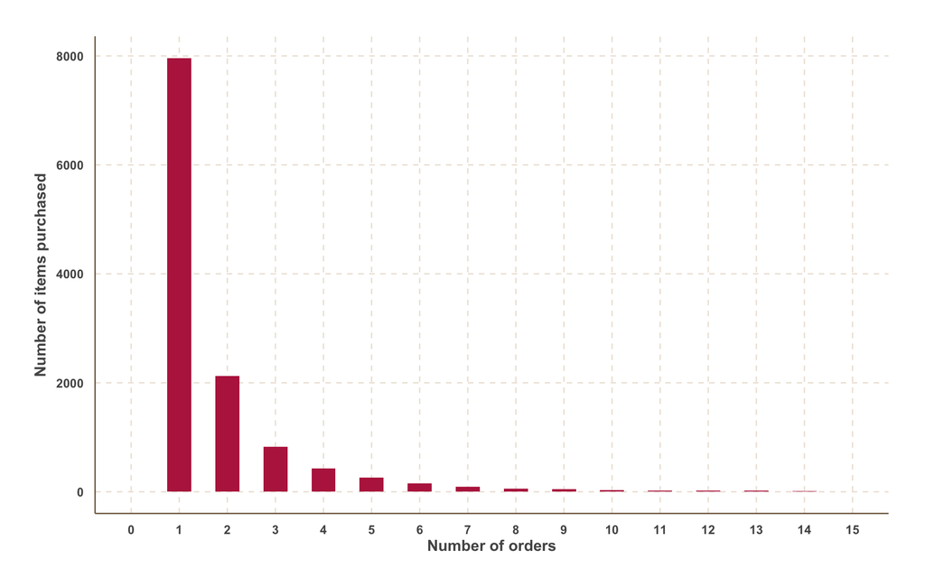

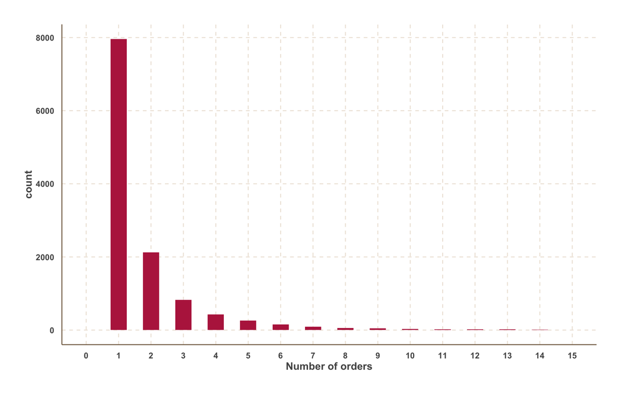

## Distribution of number of orders per customer

A total of 16098 orders have been made over the period The majority of customers have only made 1 order

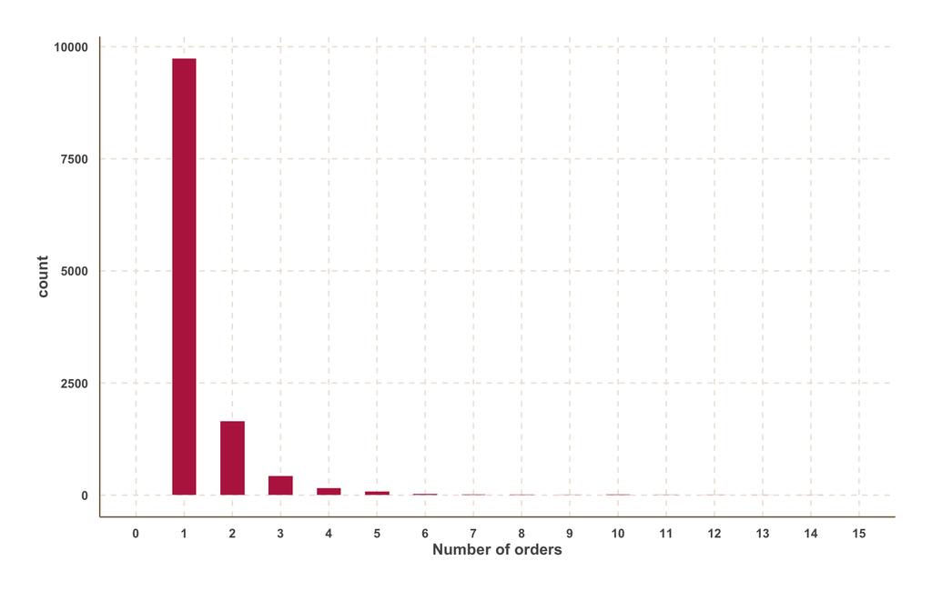

## Top 10 customers (by number of items ordered)

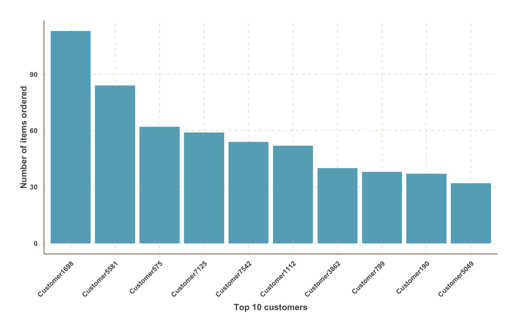

## Top 10 SKUs (by number of items ordered)

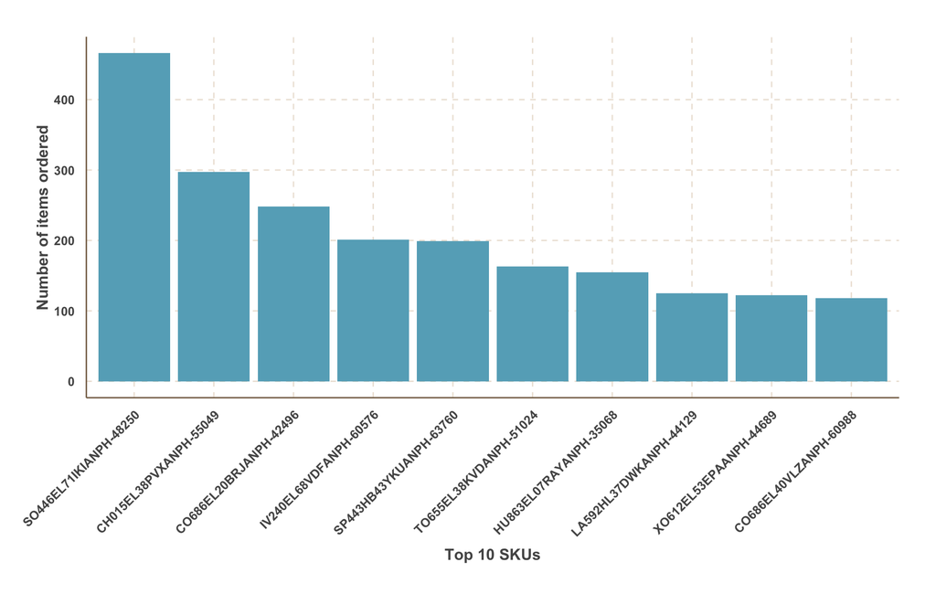

# Segmentation of the customers

The goal of our analysis is to build an algorithm that would suggest other purchases to existing customers.

Our data goes from January 1st to February 7th. We will divide the dataset in two: * First dataset regroups people who bought items in January and in February * Second dataset regroups people who ordered more than one items during January, excluding the customers who are already in the first dataset.

## Data vizualization

We can display data like: * Number of items sold per customer on average * Distribution of number of items sold * Amount spent per customer * …

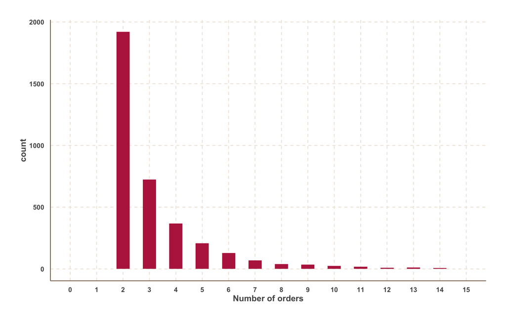

```r
# Plot of the distribution of number of items purchased on the whole period by each customer
Items_sold_per_customer_category = as.data.frame(apply(Matrix_segm,1,sum))
names(Items_sold_per_customer_category)<-"Number_of_Items_Purchased"

ggplot(Items_sold_per_customer_category, aes(Items_sold_per_customer_category$Number_of_Items_Purchased)) + geom_histogram(fill = '#B8274C', binwidth = 0.5) + scale_x_continuous(breaks = seq(0,15), limits = c(0, 15)) + labs(x = "Number of orders")
```

# Use of categories instead of item name

To make our computatinos easier, we will associate each item to its category, thus drastically reducing the number of columns in the matrix.

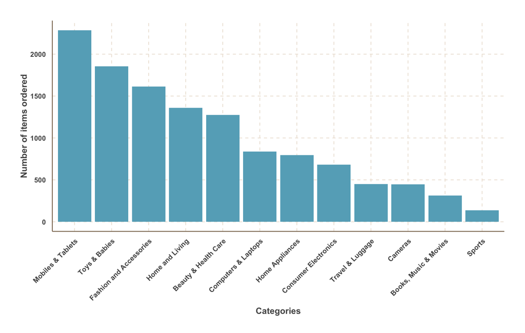

## PCA analysis

Let’s look at the **variance explained** as well as the **eigenvalues** :

|  | Eigenvalue | Pct of explained variance | Cumulative pct of explained variance |
| --- | --- | --- | --- |
| Component 1 | 1.46 | 12.16 | 12.16 |
| Component 2 | 1.16 | 9.67 | 21.83 |
| Component 3 | 1.11 | 9.25 | 31.09 |
| Component 4 | 1.09 | 9.11 | 40.19 |
| Component 5 | 1.08 | 9.03 | 49.22 |
| Component 6 | 1.00 | 8.31 | 57.53 |
| Component 7 | 0.98 | 8.18 | 65.71 |
| Component 8 | 0.96 | 8.02 | 73.73 |
| Component 9 | 0.90 | 7.53 | 81.26 |
| Component 10 | 0.88 | 7.31 | 88.57 |
| Component 11 | 0.75 | 6.25 | 94.82 |
| Component 12 | 0.62 | 5.18 | 100.00 |

[interactive chart not shown]

# Use of Sub-categories

Not every item has a sub_category in the file “Categories_all.csv”, so we will define the subcategory as the concatenation of the Category and the Subcategory found in the datafile.

It means that if an item doesn’t have a subcategory, it will be referenced by its category.

## PCA analysis

Let’s look at the **variance explained** as well as the **eigenvalues** :

|  | Eigenvalue | Pct of explained variance | Cumulative pct of explained variance |
| --- | --- | --- | --- |
| Component 1 | 2.21 | 2.28 | 2.28 |
| Component 2 | 1.91 | 1.97 | 4.25 |
| Component 3 | 1.77 | 1.82 | 6.07 |
| Component 4 | 1.58 | 1.63 | 7.70 |
| Component 5 | 1.53 | 1.58 | 9.28 |
| Component 6 | 1.51 | 1.56 | 10.84 |
| Component 7 | 1.47 | 1.51 | 12.36 |
| Component 8 | 1.42 | 1.47 | 13.82 |
| Component 9 | 1.36 | 1.40 | 15.23 |
| Component 10 | 1.32 | 1.36 | 16.58 |
| Component 11 | 1.30 | 1.34 | 17.92 |
| Component 12 | 1.25 | 1.29 | 19.21 |
| Component 13 | 1.23 | 1.27 | 20.48 |
| Component 14 | 1.22 | 1.26 | 21.74 |
| Component 15 | 1.19 | 1.23 | 22.97 |
| Component 16 | 1.18 | 1.21 | 24.18 |
| Component 17 | 1.17 | 1.20 | 25.39 |
| Component 18 | 1.16 | 1.19 | 26.58 |
| Component 19 | 1.15 | 1.18 | 27.76 |
| Component 20 | 1.14 | 1.17 | 28.93 |
| Component 21 | 1.13 | 1.17 | 30.10 |
| Component 22 | 1.12 | 1.15 | 31.25 |
| Component 23 | 1.11 | 1.14 | 32.39 |
| Component 24 | 1.10 | 1.14 | 33.53 |
| Component 25 | 1.09 | 1.13 | 34.66 |
| Component 26 | 1.08 | 1.11 | 35.77 |
| Component 27 | 1.08 | 1.11 | 36.88 |
| Component 28 | 1.07 | 1.10 | 37.98 |
| Component 29 | 1.07 | 1.10 | 39.08 |
| Component 30 | 1.06 | 1.09 | 40.18 |

[output cut: 67 more lines]

[interactive chart not shown]

[output not shown]